### 3.1 Choosing New Variables

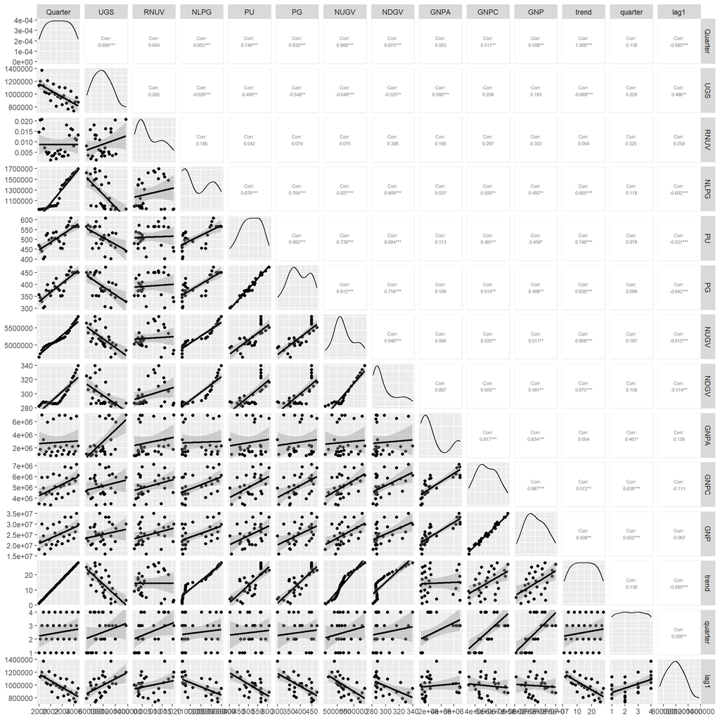

```
##
## Call:
## lm(formula = UGS ~ trend + as.factor(quarter) + PG + NUGV + lag1,
##     data = mydata)
##
## Residuals:
##    Min     1Q Median     3Q    Max
## -77288 -18935  -7548  21137  68625
##
## Coefficients:
##                       Estimate Std. Error t value Pr(>|t|)
## (Intercept)          4.171e+05  5.271e+05   0.791   0.4386
## trend               -1.047e+04  5.238e+03  -1.998   0.0602 .
## as.factor(quarter)2  1.611e+05  2.775e+04   5.805 1.36e-05 ***
## as.factor(quarter)3  2.896e+05  2.520e+04  11.490 5.37e-10 ***
## as.factor(quarter)4  6.249e+04  4.539e+04   1.377   0.1846
## PG                  -7.173e+02  3.208e+02  -2.236   0.0375 *
## NUGV                 1.267e-01  1.104e-01   1.147   0.2655
## lag1                 2.125e-01  2.044e-01   1.040   0.3115
## ---
## Signif. codes:  0 '***' 0.001 '**' 0.01 '*' 0.05 '.' 0.1 ' ' 1
##
## Residual standard error: 40720 on 19 degrees of freedom
##   (1 observation deleted due to missingness)
## Multiple R-squared:  0.9471, Adjusted R-squared:  0.9275
## F-statistic: 48.55 on 7 and 19 DF,  p-value: 8.464e-11
```

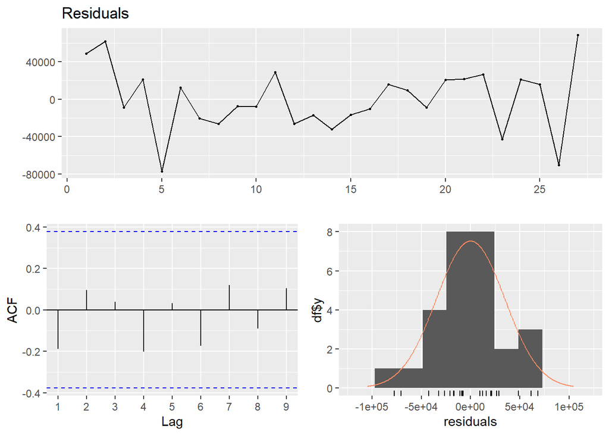

```
##
##  Breusch-Godfrey test for serial correlation of order up to 11
##
## data:  Residuals
## LM test = 9.8706, df = 11, p-value = 0.5421
```

In this model, it can be observed that there is no significant correlation between the residuals. Adjusted R^2 value is good, but open to improvement. However, the main issue is that most of the variables don’t have any significance. As a next step, NLPG and NDGV can be added to the model to see if it improves.

```
##
## Call:
## lm(formula = UGS ~ trend + as.factor(quarter) + NLPG + NDGV +
##     NUGV + PG + lag1, data = mydata)
##
## Residuals:
##    Min     1Q Median     3Q    Max
## -49526 -15476   1921  14636  38171
##
## Coefficients:
##                       Estimate Std. Error t value Pr(>|t|)
## (Intercept)          3.778e+06  8.078e+05   4.677 0.000216 ***
## trend                8.159e+03  9.025e+03   0.904 0.378562
## as.factor(quarter)2  8.084e+04  2.381e+04   3.395 0.003443 **
## as.factor(quarter)3  3.043e+05  1.697e+04  17.937 1.76e-12 ***
## as.factor(quarter)4  2.005e+05  4.010e+04   5.000 0.000110 ***
## NLPG                -2.524e-01  1.410e-01  -1.790 0.091265 .
## NDGV                 1.446e+04  3.272e+03   4.420 0.000375 ***
## NUGV                -1.194e+00  3.057e-01  -3.907 0.001135 **
## PG                  -9.503e+02  2.302e+02  -4.128 0.000704 ***
## lag1                -4.746e-01  1.907e-01  -2.489 0.023474 *
## ---
## Signif. codes:  0 '***' 0.001 '**' 0.01 '*' 0.05 '.' 0.1 ' ' 1
##
## Residual standard error: 26680 on 17 degrees of freedom
##   (1 observation deleted due to missingness)
## Multiple R-squared:  0.9797, Adjusted R-squared:  0.9689
## F-statistic: 91.03 on 9 and 17 DF,  p-value: 1.346e-12
```

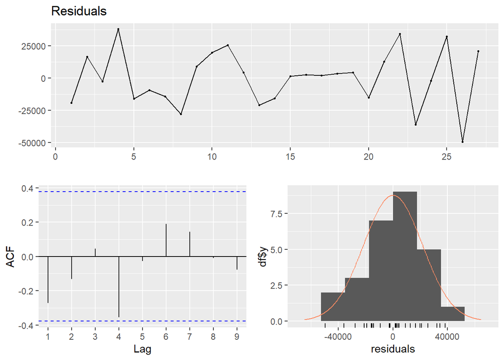

```
##
##  Breusch-Godfrey test for serial correlation of order up to 13
##
## data:  Residuals
## LM test = 23.531, df = 13, p-value = 0.03573
```

```
##
## Call:
## lm(formula = UGS ~ as.factor(quarter) + NLPG + NDGV + NUGV +
##     PG + lag1, data = mydata)
##
## Residuals:
##    Min     1Q Median     3Q    Max
## -47172 -14829   -338  15507  35301
##
## Coefficients:
##                       Estimate Std. Error t value Pr(>|t|)
## (Intercept)          3.228e+06  5.289e+05   6.104 9.11e-06 ***
## as.factor(quarter)2  8.356e+04  2.350e+04   3.556 0.002256 **
## as.factor(quarter)3  3.063e+05  1.674e+04  18.296 4.45e-13 ***
## as.factor(quarter)4  2.000e+05  3.989e+04   5.013 9.03e-05 ***
## NLPG                -1.350e-01  5.463e-02  -2.471 0.023715 *
## NDGV                 1.216e+04  2.038e+03   5.966 1.21e-05 ***
## NUGV                -9.666e-01  1.722e-01  -5.612 2.52e-05 ***
## PG                  -8.664e+02  2.097e+02  -4.133 0.000625 ***
## lag1                -4.824e-01  1.895e-01  -2.546 0.020285 *
## ---
## Signif. codes:  0 '***' 0.001 '**' 0.01 '*' 0.05 '.' 0.1 ' ' 1
##
## Residual standard error: 26540 on 18 degrees of freedom
##   (1 observation deleted due to missingness)
## Multiple R-squared:  0.9787, Adjusted R-squared:  0.9692
## F-statistic: 103.4 on 8 and 18 DF,  p-value: 1.878e-13
```

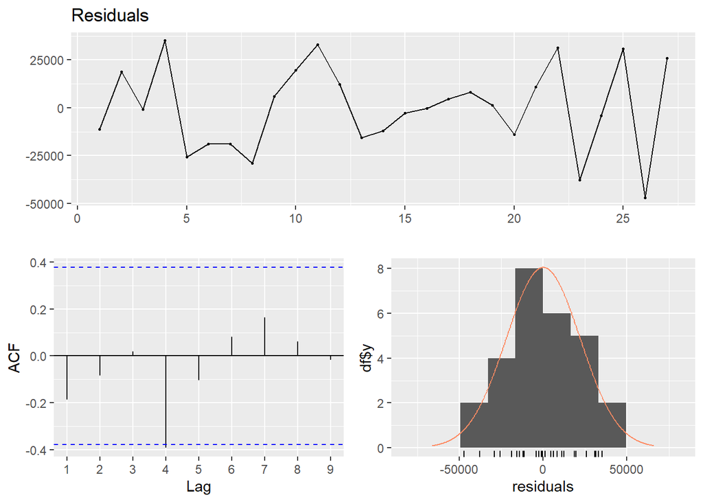

```
##
##  Breusch-Godfrey test for serial correlation of order up to 12
##
## data:  Residuals
## LM test = 19.548, df = 12, p-value = 0.07614
```

Although adjusted R^2 value has increased very slightly after excluding the trend, residuals seem to be autocorrelated at lag 4. Since this is against the underlying assumptions of the linear regression model, a lag 4 variable can be added to the model.

```
##
## Call:
## lm(formula = UGS ~ as.factor(quarter) + NLPG + NDGV + NUGV +
##     PG + lag1 + lag4, data = mydata)
##
## Residuals:
##    Min     1Q Median     3Q    Max
## -41203 -13368  -3070  15587  41974
##
## Coefficients:
##                       Estimate Std. Error t value Pr(>|t|)
## (Intercept)          3.702e+06  8.758e+05   4.227 0.000845 ***
## as.factor(quarter)2  1.030e+05  3.198e+04   3.222 0.006145 **
## as.factor(quarter)3  3.485e+05  5.661e+04   6.155  2.5e-05 ***
## as.factor(quarter)4  2.172e+05  5.046e+04   4.305 0.000726 ***
## NLPG                -1.621e-01  7.015e-02  -2.310 0.036636 *
## NDGV                 1.443e+04  4.158e+03   3.471 0.003747 **
## NUGV                -1.154e+00  3.422e-01  -3.373 0.004550 **
## PG                  -8.215e+02  2.396e+02  -3.429 0.004073 **
## lag1                -4.889e-01  2.165e-01  -2.259 0.040392 *
## lag4                -1.633e-01  1.849e-01  -0.883 0.391903
## ---
## Signif. codes:  0 '***' 0.001 '**' 0.01 '*' 0.05 '.' 0.1 ' ' 1
##
## Residual standard error: 28580 on 14 degrees of freedom
##   (4 observations deleted due to missingness)
## Multiple R-squared:  0.9675, Adjusted R-squared:  0.9467
## F-statistic: 46.37 on 9 and 14 DF,  p-value: 6.96e-09
```

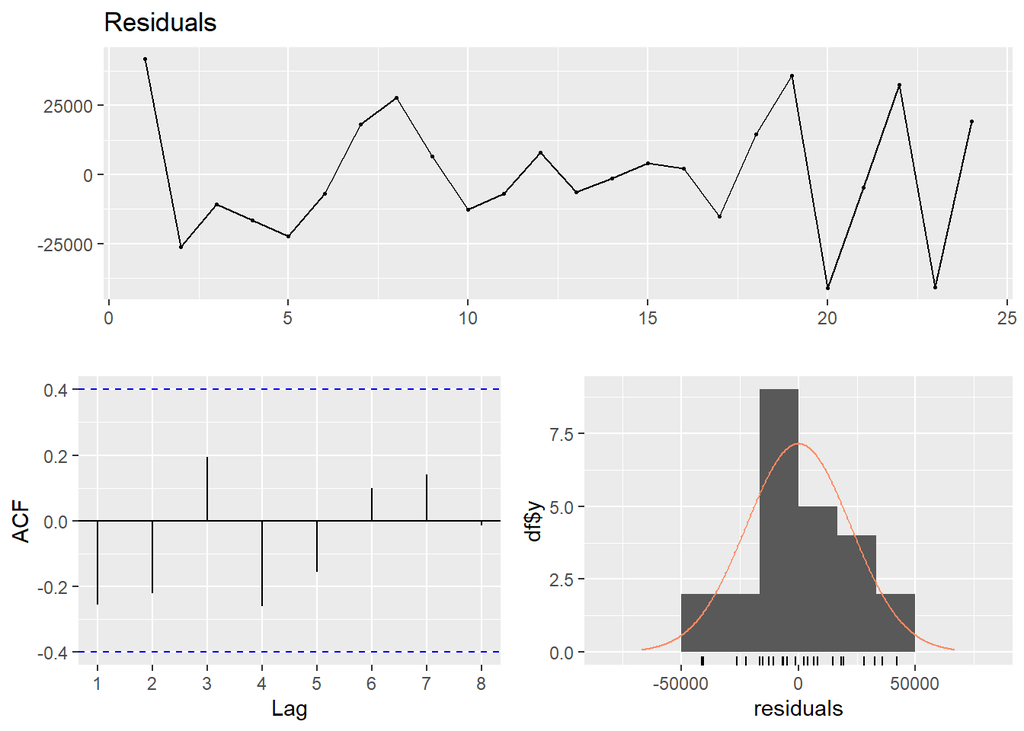

```
##
##  Breusch-Godfrey test for serial correlation of order up to 13
##
## data:  Residuals
## LM test = 23.273, df = 13, p-value = 0.03852
```

In this updated model, lag 4 seems to have no significance and adjusted R^2 value dropped significantly when compared to the second model. To see if the problem will be resolved if we excluded lag 1, another model is constructed.

[output not shown]

[figure not shown]

[output not shown]

Before stating the final linear regression model, it is important to point out the fact that there can be many combinations of this linear regression model. However, analyzing each of them would make this report very long. Due to this, I analyzed various models and after obtaining enough significance of the variables and a good adjusted R^2 value, I concluded the model selection process. The reason why more independent variables are not added to the model is that the more variables we add to the system, more likely that the other variables will lose significance since some variables can also be correlated within themselves. In addition, another aim in constructing a linear regression model is to make it as simple as possible.

### 3.2 Final Regression Model

Out of all the regression models, the model given below turned out to be the most suitable one.

```r
final_model <- lm(formula = UGS ~ trend + as.factor(quarter) + NLPG + NDGV + NUGV + PG + lag1, mydata)
summary(final_model)
```

```
##
## Call:
## lm(formula = UGS ~ trend + as.factor(quarter) + NLPG + NDGV +
##     NUGV + PG + lag1, data = mydata)
##
## Residuals:
##    Min     1Q Median     3Q    Max
## -49526 -15476   1921  14636  38171
##
## Coefficients:
##                       Estimate Std. Error t value Pr(>|t|)
## (Intercept)          3.778e+06  8.078e+05   4.677 0.000216 ***
## trend                8.159e+03  9.025e+03   0.904 0.378562
## as.factor(quarter)2  8.084e+04  2.381e+04   3.395 0.003443 **
## as.factor(quarter)3  3.043e+05  1.697e+04  17.937 1.76e-12 ***
## as.factor(quarter)4  2.005e+05  4.010e+04   5.000 0.000110 ***
## NLPG                -2.524e-01  1.410e-01  -1.790 0.091265 .
## NDGV                 1.446e+04  3.272e+03   4.420 0.000375 ***
## NUGV                -1.194e+00  3.057e-01  -3.907 0.001135 **
## PG                  -9.503e+02  2.302e+02  -4.128 0.000704 ***
## lag1                -4.746e-01  1.907e-01  -2.489 0.023474 *
## ---
## Signif. codes:  0 '***' 0.001 '**' 0.01 '*' 0.05 '.' 0.1 ' ' 1
##
## Residual standard error: 26680 on 17 degrees of freedom
##   (1 observation deleted due to missingness)
## Multiple R-squared:  0.9797, Adjusted R-squared:  0.9689
## F-statistic: 91.03 on 9 and 17 DF,  p-value: 1.346e-12
```

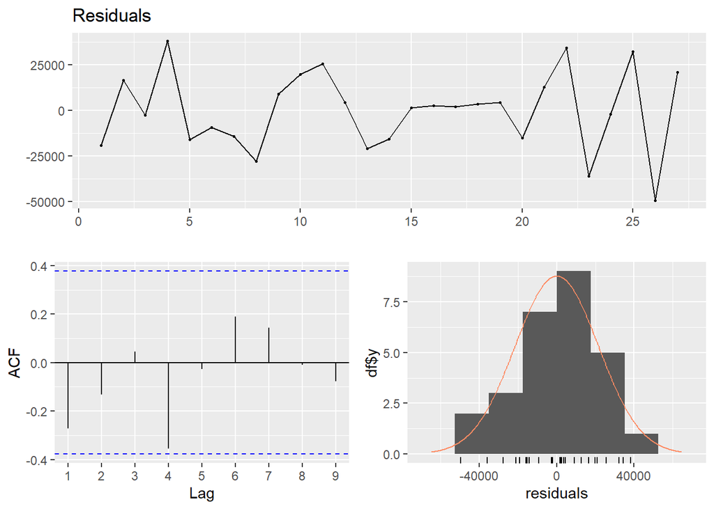

```
##
##  Breusch-Godfrey test for serial correlation of order up to 13
##
## data:  Residuals
## LM test = 23.531, df = 13, p-value = 0.03573
```

```r
checkresiduals(final_model)
```

### 3.3 Residual Analysis

Before moving on to the prediction, another residual analysis can be conducted to make sure our model is suitable. Down below, residuals versus the regressor variables are plotted.

[figure not shown]

[figure not shown]

[figure not shown]

[figure not shown]

[figure not shown]

[figure not shown]

[figure not shown]

It can be said that regressors other than NLPG, NUGV and NDGV generally tend to have a same scattered distribution, resembling a rectangular shape, as in mean zero and constant variance distribution. Residuals vs. NLPG plot does not seem problematic, it again tends to scatter in an uncorrelated way, only slightly accumulated at the beginning and the end of the plot. In residuals vs. NDGV plot, residuals seem to accumulate at the beginning, however in the remaining part of the plot residuals are scattered. Even though this plot is not completely ideal, it does not cause a major problem in the model. If we try to exclude it, adjusted R^2 value drastically drops. So, for the sake of the model’s validity, it is best to keep NDGV. In residuals vs NUGV plot, residuals are distributed with mean zero, however they seem slightly accumulated in the middle. Again, since this does not cause any major issues in the overall model, NUGV is not discarded.

## 4. Forecasting with Regression Model

```r
hw2data$trend <- 1:32
quarter <- seq(1,4, by=1)
hw2data <- cbind(hw2data,quarter)
hw2data$lag1 <- c(NA,mydata$UGS[1:28],NA,NA,NA)

test_data <- hw2data[29:32,c("trend","quarter","NLPG","NDGV","NUGV","PG","lag1")]

prediction <- c(0,0,0,0)

prediction[1] <- predict(final_model,newdata = test_data[1,])
test_data[2,"lag1"] <- prediction[1]

prediction[2] = predict(final_model,newdata = test_data[2,])
test_data[3,"lag1"] <- prediction[2]

prediction[3] = predict(final_model,newdata = test_data[3,])
test_data[4,"lag1"] <- prediction[3]

prediction[4] <- predict(final_model,newdata = test_data[4,])
```

Predicted values of UGS of the next four quarters is given below. Since the model needed lag 1 data, at each iteration I also used the previous quarter’s predicted value.

```r
print(prediction)
```

```
## [1] 680459.0 852272.7 989421.3 812740.9
```

## 5. Conclusion

Predicted UGS values and actual UGS values are plotted in the same graph to visually observe the validity of the final linear regression model.

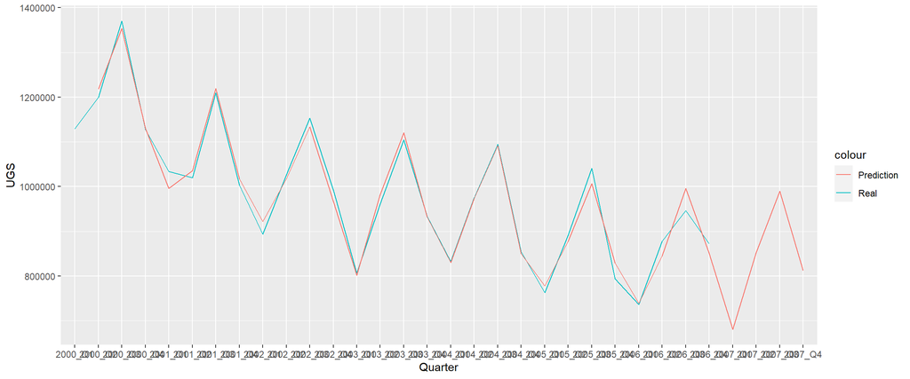

It can be clearly seen that the linear regression model works well, since it has a very similar shape to the actual time series.

In this assignment, after choosing the appropriate regressors for the linear regression model with the help of correlation tests, UGS values of the four quarters of 2007 were predicted.

## 6. Appendices

[Here](https://bu-ie-360.github.io/fall20-nilufercetin/files/HMW3.Rmd) RMD file written for this assignment including the code chunks can be found.

[Here](https://bu-ie-360.github.io/fall20-araldortogul/files/R-scripts/homework3.R) (.R file). All the R code written can be found.